# Assignment_5

Nicolas Mollier

16/2/2021

# Declaration and Project Repository

For this assignment, I worked together with Max Kneißler (Student ID: 4121846). The link to my project repository is https://github.com/nicolasmollier/DSPM_Assignment_5

```r
rm(list = ls())
```

```r
library(tidyverse)
library(knitr)
library(jsonlite)
library(httr)
library(rlist)
```

# Task 2) Ticketmaster API

In the section “Discovery API” subsection “Venue Search”, query parameters that can be used are listed. The query parameters that we are going to use are `locale`, `size`, `page` and `countryCode`. The default quota is 5000 API calls per day and rate limitation of 5 requests per second. Therefore, I originally used `Sys.Sleep(1/5)` in order to make sure that the rate limitation of 5 requests per second is not violated. Theoretically, with `Sys.Sleep(1/5)` in place between each request to the ticketmaster API, it is not possible to make more than 5 requests per second even if the pure execution time of the code that performs the request was virtually zero. Since using `Sys.Sleep(1/5)` repeatedly caused “Spike arrest violations”, I instead used `Sys.Sleep(2/5)` which seemed to reduce the frequency of the occurrence of that error. Note, when a “Spike arrest violation” occurred, the response object did contain an error message but not the content about venues. Extracting the content from that response object resulted in a NULL object. Since we cannot subset a Null object based on our desired variables, we get a error message that R cannot subset columns that do not exist. Therefore, in those cases the knitting stopped. Trying to knit the document one or two times again after the “Spike arrest violation error” occurred, the code ran without problems and the HTML document was knitted. I could not figure out what caused the “Spike arrest violations” and why they seemed to occur randomly. For example, the page size used in the GET request did not eliminate the problem. Theoretically, a pause of 2/5 seconds between each request should be more than enough to prevent more than 5 requests per second.

Before we can start making requests in Task 3, we need to make the API key -that we retrieved from the API Explorer and saved in the file `api_key.R`- available in our script as `tm_api_key`.

```r
source("api_key.R")
```

# Task 3) First GET request for Germany

First of all, I define the two variables `country_code` and `page_size` for Task 3. `page_size` can be used inside API requests for the `size` parameter which enables me to extract 100 cases per request instead of 20 (default). Defining the `country_code` variable enables me to quickly adapt the code for request of venues in other countries.

```r
country_code <- "DE"
page_size <- 100
```

For the first GET request, we use the `tm_api_key` as `apikey`, `country_code` set to “DE” as `countryCode` value and `page_size` set to as value for the `size` parameter. Additionally, we have to set `locale = '*'`. Otherwise, we do not get all German venues that are available and almost all longitude and latitude values are missing. Setting `locale = '*'` resolves these issues. As described we have to add /discovery/v2/venues to the root url https://app.ticketmaster.com/discovery/v2/ when performing venue searches. `Sys.Sleep(2/5)` is used after the request to make sure that we adhere to the rate limit of 5 requests per second.

```r
response <- GET(url = "https://app.ticketmaster.com/discovery/v2/venues",
    query = list(apikey = tm_api_key,
                 countryCode = country_code,
                 size = page_size,
                 locale = '*'))
Sys.sleep(2/5)
```

```r
content_json <- content(response, as = "text")
content <- fromJSON(content_json)
venues_df <-content[["_embedded"]][["venues"]]
venues_select <- venues_df %>%
  select(name, city, postalCode, address, url, location)
glimpse(venues_select)
```

```
## Rows: 100
## Columns: 6
## $ name       <chr> "Gruenspan", "Philharmonie (Großer Saal)", "Beatpol", "MHP…
## $ city       <df[,1]> <data.frame[26 x 1]>
## $ postalCode <chr> "22767", "10785", "01157", "71638", "12435", "79108", "701…
## $ address    <df[,1]> <data.frame[26 x 1]>
## $ url        <chr> "http://www.ticketmaster.de/venue/287155", "https://www.ti…
## $ location   <df[,2]> <data.frame[26 x 2]>
```

The vector variables `name`, `postalCode` and `url` can be selected directly.

```r
venue_data <- venues_select %>%
  select(where(is.vector))
```

The other variables `city`, `address`, `longitude` and `latitude` have to be selected by first accessing the respective column that is itself a data frame and then accessing the respective column inside that data frame. The resulting vectors are saved as columns in `venue_data`.

```r
venue_data["city"] <- venues_select$city[["name"]]
venue_data["address"] <- venues_select$address[["line1"]]
venue_data["longitude"] <- venues_select$location["longitude"]
venue_data["latitude"] <- venues_select$location["latitude"]


venue_data %>%
  glimpse()
```

```
## Rows: 100
## Columns: 7
## $ name       <chr> "Gruenspan", "Philharmonie (Großer Saal)", "Beatpol", "MHP…
## $ postalCode <chr> "22767", "10785", "01157", "71638", "12435", "79108", "701…
## $ url        <chr> "http://www.ticketmaster.de/venue/287155", "https://www.ti…
## $ city       <chr> "Hamburg", "Berlin", "Dresden", "Ludwigsburg", "Berlin", "…
## $ address    <chr> "Grosse Freiheit 58", "Herbert-von-Karajan-Straße 1", "Alt…
## $ longitude  <chr> "9.958075", "13.36896", "13.67471", "9.1824", "13.42054", …
## $ latitude   <chr> "53.551885", "52.51007", "51.06498", "48.89121", "52.49945…
```

`venue_data` has 100 rows and 7 columns.

# Task 4) Retrieving all German venues

A look at the list element `page` in the object `content` reveals that we extracted 100 venues out of 12238 from 123 pages with at most 100 venues each. We can extract the venues from all the pages available by looping through them. In order to do this, we write a for loop that starts with the query parameter `page` set to 0 and increases the value after each iteration until we reach the last page. Since the first page has the index 0, we need to start the iteration through all pages at `page = 0`. The parameter `locale` is set to `'*'` to make sure that we retrieve all German venues.

We start by extracting the total number of pages for Germany and save it as `total_pages`. The total number of venues (elements) is saved as `n`. After that, two data frames are created. `venue_data_complete` will hold all venues from all the pages of venues in Germany. Therefore, we initialize it with variables (columns) of lengths `n`. The data frame `venue_data` is just a temporary data frame to hold the elements of the respective page in the respective iteration of the loop.

```r
total_pages <- content$page$totalPages
n <- content$page$totalElements

venue_data_complete <-
  data.frame(
    name = character(n),
    city = character(n),
    postalCode = character(n),
    address = character(n),
    url = character(n),
    longitude = numeric(n),
    latitude = numeric(n),
    stringsAsFactors = FALSE
  )
venue_data <-
  data.frame(
    name = character(page_size),
    city = character(page_size),
    postalCode = character(page_size),
    address = character(page_size),
    url = character(page_size),
    longitude = numeric(page_size),
    latitude = numeric(page_size),
    stringsAsFactors = FALSE
  )
```

Overall, there are 12238 venues to be retrieved from 123 pages. We start the iteration at page 0 and end it at page 122. In each iteration, we use the same GET request that we used above, except that now the parameter `page` is set to the respective page in each iteration. The extraction of the variables of interest from the `response` object is done in the same way as well. The if statement is needed to accommodate the fact that the last page generally does not have 100 but less elements. As long as we are not at the last page, we obtain a temporary data frame called `venue_data` with 100 rows that contains the seven variables. For the last page, the initialization of this temporary data frame `venue_data` is different, since the number of rows has to be adapted to the number of cases in the last page. We can get the necessary row number by calculating the remainder of the division of the total number of elements and the page size (here: 100) (`n %% page_size`). The result of this loop is a data frame called `venue_data_complete` that contains every German venue. Note, that I used `Sys.sleep(2/5)` instead of `Sys.sleep(1/5)`. Theoretically, with `Sys.Sleep(1/5)` in place between each request to the ticketmaster API, it is not possible to make more than 5 requests per second. However, using `Sys.Sleep(1/5)` repeatedly prompted “Spike arrest violations” when running the loop for the German venues. Using `Sys.sleep(2/5)` seems to reduce the frequency of facing such an error but it still happened from time to time, especially when I ran the code of my entire script more than once per day.

```r
for(i in 0:(total_pages-1)){
  response <- GET(url = "https://app.ticketmaster.com/discovery/v2/venues",
    query = list(apikey = tm_api_key,
                 countryCode = country_code,
                 size = page_size,
                 page = i,
                 locale = '*'))
  content_json <- content(response, as = "text")
  content <- fromJSON(content_json)
  content_embedded <- content[["_embedded"]]
  # assign(paste0("venues",i), content_embedded[["venues"]])
  venues <- content_embedded[["venues"]]
  # as long as we have not reached the last page, we insert data frames
  # with 100 cases into venue_data_complete
  if(i < (total_pages-1)){
    venue_data["name"] <- venues[["name"]]
    venue_data["postalCode"] <- venues[["postalCode"]]
    venue_data["url"] <- venues[["url"]]
    venue_data["city"] <- venues$city[["name"]]
    venue_data["address"] <- venues$address[["line1"]]
    venue_data["longitude"] <- as.double(venues$location[["longitude"]])
    venue_data["latitude"] <- as.double(venues$location[["latitude"]])
    venue_data <- venue_data %>%
      select(name, city, postalCode, address, url, longitude, latitude)
    # put the content of the temporary data frame in the right spot in venue_data_complete
    venue_data_complete[(i*page_size + 1) : ((i+1) * page_size), ] <- venue_data
    # print(paste("Page:", i+1, "| Progress:", scales::percent(i/total_pages), sep = " "))
    Sys.sleep(2/5)
  # as soon as we reach the last page, the number of rows to be inserted into
  # venue_data_complete reduces to n %% page_size (the remainder of the division of
  # the total number of elements and the page size)
  } else{
    venue_data <- data.frame(
      name = character(n%%page_size),
      city = character(n%%page_size),
      postalCode = character(n%%page_size),
      address = character(n%%page_size),
      url = character(n%%page_size),
      longitude = numeric(n%%page_size),
      latitude = numeric(n%%page_size),
      stringsAsFactors = FALSE
      )

    venue_data["name"] <- venues[["name"]]
    venue_data["postalCode"] <- venues[["postalCode"]]
    venue_data["url"] <- venues[["url"]]
    venue_data["city"] <- venues$city[["name"]]
    venue_data["address"] <- venues$address[["line1"]]
    venue_data["longitude"] <- as.double(venues$location[["longitude"]])
    venue_data["latitude"] <- as.double(venues$location[["latitude"]])
    venue_data <- venue_data %>%
      select(name, city, postalCode, address, url, longitude, latitude)
    # put the content of the temporary data frame for the last page in the right spot in venue_data_complete
    venue_data_complete[(i*page_size + 1) : (i*page_size + n%%page_size), ] <- venue_data
    # print("final iteration")
    Sys.sleep(2/5)
  }
}
```

The final data frame containing all German venues has 12238 rows.

```r
glimpse(venue_data_complete)
```

```
## Rows: 12,238
## Columns: 7
## $ name       <chr> "Gruenspan", "Philharmonie (Großer Saal)", "Beatpol", "MHP…
## $ city       <chr> "Hamburg", "Berlin", "Dresden", "Ludwigsburg", "Berlin", "…
## $ postalCode <chr> "22767", "10785", "01157", "71638", "12435", "79108", "701…
## $ address    <chr> "Grosse Freiheit 58", "Herbert-von-Karajan-Straße 1", "Alt…
## $ url        <chr> "http://www.ticketmaster.de/venue/287155", "https://www.ti…
## $ longitude  <dbl> 9.958075, 13.368960, 13.674710, 9.182400, 13.420540, 7.840…
## $ latitude   <dbl> 53.55188, 52.51007, 51.06498, 48.89121, 52.49945, 48.01587…
```

# Task 5) Visualizing the extracted German data

Next, let us visualize the locations of the extracted venues. Some coordinates are outside the boundaries of the German borders. Venues with coordinates that are outside the extreme point ranges that were derived from the extreme points for Germany listed on https://en.wikipedia.org/wiki/Geography_of_Germany#Extreme_points are not included in the following map.

```r
max_lat_de <- 55.0846
min_lat_de <- 47.271679
min_long_de <- 5.866944
max_long_de <- 15.043611

# keep only the venues with location coordinates inside the area that is defined
# by the extreme points
venue_data_complete <- venue_data_complete %>%
  filter(longitude < max_long_de, longitude > min_long_de,
         latitude < max_lat_de, latitude > min_lat_de)
```

The venue locations are indicated on the map by points. The opacity of the points was reduced to make locations with a high concentration of venues more visible.

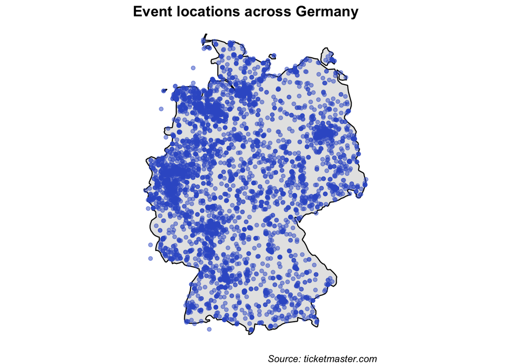

```r
ggplot() +
  geom_polygon(
    aes(x = long, y = lat, group = group), data = map_data("world", region = "Germany"),
    fill = "gray90",color = "black") +
  geom_point(data = venue_data_complete, aes(longitude, latitude),
             color = "royalblue3",
             alpha = 0.5) +
  theme_void() + coord_quickmap() +
  labs(title = "Event locations across Germany", caption = "Source: ticketmaster.com") +
  theme(title = element_text(size=12, face='bold'),
    plot.caption = element_text(face = "italic"))
```

# Task 6) Event locations in Belgium

We repeat everything that we have done previously for German venues but set the `country_code` to “BE” this time to retrieve venues in Belgium. Another thing that we have to adapt are the extreme points to filter out those venues with location coordinates that are way outside the country borders of Belgium. Otherwise, the code is not changed compared to the German case.

```r
country_code <- "BE"
```

```r
Sys.sleep(4)  # safety not to avoid spike arrest violation
response <- GET(url = "https://app.ticketmaster.com/discovery/v2/venues",
    query = list(apikey = tm_api_key,
                 countryCode = country_code,
                 size = page_size,
                 locale = '*'))
Sys.sleep(2/5)
```

```r
content_json <- content(response, as = "text")
content <- fromJSON(content_json)
venues <-content[["_embedded"]]
venues <- venues[["venues"]]
venues_select <- venues %>%
  select(name, city, postalCode, address, url, location)
glimpse(venues_select)
```

```
## Rows: 100
## Columns: 6
## $ name       <chr> "Basilique", "Site du festival", "La Madeleine", "Grand-Pl…
## $ city       <df[,1]> <data.frame[26 x 1]>
## $ postalCode <chr> "6870", "6880", "1000", "1000", "4000", "1495", "6000", "7…
## $ address    <df[,1]> <data.frame[26 x 1]>
## $ url        <chr> "https://www.ticketmaster.be/venue/basilique-saint-hubert-…
## $ location   <df[,2]> <data.frame[26 x 2]>
```

```r
venue_data <- venues_select %>%
  select(where(is.vector))

venue_data["city"] <- venues_select$city[["name"]]
venue_data["address"] <- venues_select$address[["line1"]]
venue_data["longitude"] <- venues_select$location["longitude"]
venue_data["latitude"] <- venues_select$location["latitude"]


glimpse(venue_data)
```

```
## Rows: 100
## Columns: 7
## $ name       <chr> "Basilique", "Site du festival", "La Madeleine", "Grand-Pl…
## $ postalCode <chr> "6870", "6880", "1000", "1000", "4000", "1495", "6000", "7…
## $ url        <chr> "https://www.ticketmaster.be/venue/basilique-saint-hubert-…
## $ city       <chr> "Saint-Hubert", "Bertrix", "Brussels", "Brussels", "Liège"…
## $ address    <chr> "Place de l'Abbaye 8", "Place des Trois Fers", "Rue Duques…
## $ longitude  <chr> "5.36094", "5.25314", "4.35439", "4.35182", "5.57168", "4.…
## $ latitude   <chr> "50.02708", "49.85464", "50.84498", "50.84698", "50.64104"…
```

```r
total_pages <- content$page$totalPages
n <- content$page$totalElements

venue_data_complete <-
  data.frame(
    name = character(n),
    city = character(n),
    postalCode = character(n),
    address = character(n),
    url = character(n),
    longitude = numeric(n),
    latitude = numeric(n),
    stringsAsFactors = FALSE
  )
venue_data <-
  data.frame(
    name = character(page_size),
    city = character(page_size),
    postalCode = character(page_size),
    address = character(page_size),
    url = character(page_size),
    longitude = numeric(page_size),
    latitude = numeric(page_size),
    stringsAsFactors = FALSE
  )
```

Overall, there are 1033 venues to be retrieved from 11 pages.

```r
for(i in 0:(total_pages-1)){
  response <- GET(url = "https://app.ticketmaster.com/discovery/v2/venues",
    query = list(apikey = tm_api_key,
                 countryCode = country_code,
                 size = page_size,
                 page = i,
                 locale = '*'))
  content_json <- content(response, as = "text")
  content <- fromJSON(content_json)
  content_embedded <- content[["_embedded"]]
  # assign(paste0("venues",i), content_embedded[["venues"]])
  venues <- content_embedded[["venues"]]

  # as long as we have not reached the last page, we insert data frames
  # with 100 cases into venue_data_complete
  if(i < (total_pages-1)){
    venue_data["name"] <- venues[["name"]]
    venue_data["postalCode"] <- venues[["postalCode"]]
    venue_data["url"] <- venues[["url"]]
    venue_data["city"] <- venues$city[["name"]]
    venue_data["address"] <- venues$address[["line1"]]
    venue_data["longitude"] <- as.double(venues$location[["longitude"]])
    venue_data["latitude"] <- as.double(venues$location[["latitude"]])
    venue_data <- venue_data %>%
      select(name, city, postalCode, address, url, longitude, latitude)
    venue_data_complete[(i*page_size + 1) : ((i+1) * page_size), ] <- venue_data
    # print(paste("Page:", i+1, "| Progress:", scales::percent(i/total_pages), sep = " "))
    Sys.sleep(2/5)
  # as soon as we reach the last page, the number of rows to be inserted into
  # venue_data_complete reduces to n %% page_size (the remainder of the division of
  # the total number of elements and the page size)
  } else{
    venue_data <- data.frame(
      name = character(n%%page_size),
      city = character(n%%page_size),
      postalCode = character(n%%page_size),
      address = character(n%%page_size),
      url = character(n%%page_size),
      longitude = numeric(n%%page_size),
      latitude = numeric(n%%page_size),
      stringsAsFactors = FALSE
      )

    venue_data["name"] <- venues[["name"]]
    venue_data["postalCode"] <- venues[["postalCode"]]
    venue_data["url"] <- venues[["url"]]
    venue_data["city"] <- venues$city[["name"]]
    venue_data["address"] <- venues$address[["line1"]]
    venue_data["longitude"] <- as.double(venues$location[["longitude"]])
    venue_data["latitude"] <- as.double(venues$location[["latitude"]])
    venue_data <- venue_data %>%
      select(name, city, postalCode, address, url, longitude, latitude)
    venue_data_complete[(i*page_size + 1) : (i*page_size + n%%page_size), ] <- venue_data
    # print("final iteration")
    Sys.sleep(2/5)
  }
}
```

The final data frame containing all venues from Belgium has 1033 rows.

```r
venue_data_complete %>%
  glimpse()
```

```
## Rows: 1,033
## Columns: 7
## $ name       <chr> "Basilique", "Site du festival", "La Madeleine", "Grand-Pl…
## $ city       <chr> "Saint-Hubert", "Bertrix", "Brussels", "Brussels", "Liège"…
## $ postalCode <chr> "6870", "6880", "1000", "1000", "4000", "1495", "6000", "7…
## $ address    <chr> "Place de l'Abbaye 8", "Place des Trois Fers", "Rue Duques…
## $ url        <chr> "https://www.ticketmaster.be/venue/basilique-saint-hubert-…
## $ longitude  <dbl> 5.36094, 5.25314, 4.35439, 4.35182, 5.57168, 4.52901, 4.44…
## $ latitude   <dbl> 50.02708, 49.85464, 50.84498, 50.84698, 50.64104, 50.59023…
```

```r
max_lat_be <- 51.4570
min_lat_be <- 49.8209
min_long_be <- 2.5804
max_long_be <- 6.4033

# max_lat_uk <- 60.85
# min_lat_uk <- 49.85
# min_long_uk <- -13.683333
# max_long_uk <- 1.766667


venue_data_complete <- venue_data_complete %>%
  filter(longitude < max_long_be, longitude > min_long_be,
         latitude < max_lat_be, latitude > min_lat_be)
```

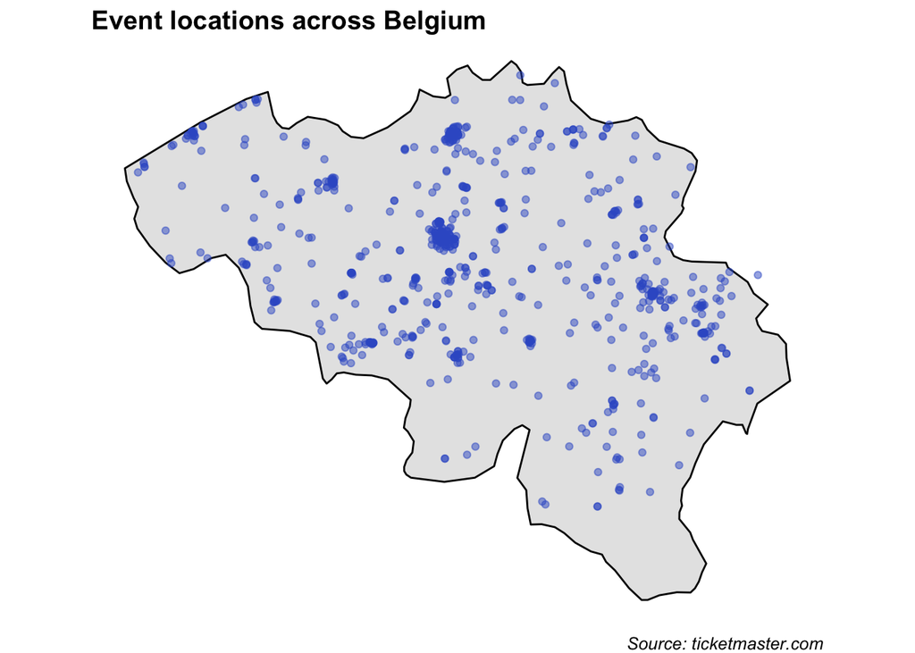

```r
ggplot() +
  geom_polygon(
    aes(x = long, y = lat, group = group), data = map_data("world", region = "Belgium"),
    fill = "gray90",color = "black") +
  geom_point(data = venue_data_complete, aes(longitude, latitude),
             color = "royalblue3",
             alpha = 0.5) +
  theme_void() + coord_quickmap() +
  labs(title = paste("Event locations across Belgium"), caption = "Source: ticketmaster.com") +
  theme(title = element_text(size=12, face='bold'),
    plot.caption = element_text(face = "italic"))
```